# Getting Started with SWORD

## Overview

**SWORD** (**S**upport vector machine **W**eighted **O**blique **R**andom **D**ecision forests) fits random forests of oblique regression trees. Each internal node uses a **Weighted-SVM** classifier with a linear kernel to define the oblique splitting hyperplane — a sparse linear combination of predictors — rather than a single axis-aligned threshold.

The base learner is **TORS** (**T**ree **O**blique for **R**egression with weighted **S**VM), a single oblique regression tree introduced in Carta & Frigau (2025). SWORD embeds TORS within a bootstrap aggregation framework, adding predictor subspacing and optional randomisation of the number of features per split to increase tree diversity.

The package provides:

- `TORS()` — fit a single TORS oblique regression tree.
- `SWORD()` — fit a SWORD forest of TORS trees with bootstrap sampling and out-of-bag (OOB) error estimation.
- `predict()` — S3 method for both objects, with automatic encoding of factor and character predictors.
- `VI_SWORD()` — Oblique Impurity-Weighted Variable Importance (OIW-VI): deviance reduction at each node, distributed among predictors proportionally to their normalised absolute Weighted-SVM coefficients.
- Plot helpers — OOB convergence, importance barplot, predicted-vs-observed scatter, and partial dependence plots.

## Data

We use the **Boston** housing dataset from the `MASS` package (506 observations, 13 numeric predictors, response `medv` = median house value). The data are split 80/20 into training and test sets.

```r
if (!requireNamespace("MASS", quietly = TRUE))
  stop("Please install the MASS package: install.packages('MASS')")

library(SWORD)
data(Boston, package = "MASS")

set.seed(42)
n     <- nrow(Boston)
train <- sample(n, floor(0.8 * n))
test  <- setdiff(seq_len(n), train)

X_train <- Boston[train, setdiff(names(Boston), "medv")]
y_train <- Boston$medv[train]
X_test  <- Boston[test,  setdiff(names(Boston), "medv")]
y_test  <- Boston$medv[test]

cat("Training set:", nrow(X_train), "obs |",
    "Test set:", nrow(X_test), "obs\n")
```

```
#> Training set: 404 obs | Test set: 102 obs
```

## Fitting a single TORS tree

`TORS()` grows one SVM oblique rotation tree. Key tuning parameters:

| Parameter | Meaning | Default |
| --- | --- | --- |
| `nmin` | minimum node size | 5 |
| `cp` | complexity threshold for splitting | 0.01 |
| `n_topCor` | top-correlated features fed to the SVM at each node | 2 |
| `relation` | feature selection criterion: `"Pearson"` or `"MI"` | `"Pearson"` |
| `Weight_Scheme` | observation weighting: `"scale"` or `"robust"` | `"scale"` |
| `cost_C` | SVM cost C | 1 |

```r
set.seed(1)
tree <- TORS(X_train, y_train, nmin = 15, cp = 0.02)
print(tree)
```

```
#> ---------- TORS (Tree Oblique for Regression with weighted SVM)
#>
#>            N observations: 404
#>              N predictors: 13
#>                   N nodes: 25 (12 internal, 13 leaves)
#>                 Max depth: 4
#>           Avg obs in leaf: 31.1
#>           Min obs in leaf: 7
#>      Top-correlated feats: 2
#>               Correlation: Pearson
#>             Weight scheme: scale
#>
#> -----------------------------------------
```

### Tree structure (text)

`plot_tors_text()` prints the tree as an indented list of nodes. Each internal node shows the oblique hyperplane equation (top-`k` largest coefficients); each leaf shows the predicted mean.

```r
plot_tors_text(tree, top_k = 3)
```

```
#> TORS — text representation
#> ------------------------------------------------------------
#> Node 1  n=404  [ - 0.957·rm + 0.282·lstat - 2.837 = 0 ]
#> L-- Node 2  n=193  [ - 1.636·rm + 0.296·lstat - 8.985 = 0 ]
#>   L-- Node 3  n=77  [ - 2.047·rm + 0.226·dis - 13.886 = 0 ]
#>     L-- Node 4  n=30  [ 0.262·ptratio + 0.683·lstat + 7.896 = 0 ]
#>       L-- Leaf  n=18  mean=45.4833
#>       R-- Leaf  n=12  mean=35.8583
#>     R-- Node 7  n=47  [ - 5.578·rm + 1.041·lstat - 33.09 = 0 ]
#>       L-- Leaf  n=26  mean=34.4731
#>       R-- Leaf  n=21  mean=27.4952
#>   R-- Node 10  n=116  [ 0.321·dis - 0.019·rad + 0.978 = 0 ]
#>     L-- Node 11  n=35  [ 1.117·dis + 0.307·lstat + 5.236 = 0 ]
#>       L-- Leaf  n=7  mean=29.8000
#>       R-- Leaf  n=28  mean=23.9643
#>     R-- Leaf  n=81  mean=22.9605
#> R-- Node 15  n=211  [ 0.085·crim + 0.267·lstat + 5.252 = 0 ]
#>   L-- Node 16  n=131  [ - 0.009·black + 0.430·lstat + 3.32 = 0 ]
#>     L-- Node 17  n=82  [ 0.529·dis + 0.254·ptratio + 6.816 = 0 ]
#>       L-- Leaf  n=56  mean=20.9036
#>       R-- Leaf  n=26  mean=19.0615
#>     R-- Leaf  n=49  mean=17.3367
#>   R-- Node 21  n=80  [ 0.013·crim + 0.007·tax + 4.194 = 0 ]
#>     L-- Leaf  n=20  mean=15.5300
#>     R-- Node 23  n=60  [ 5.951·nox + 0.270·lstat + 10.225 = 0 ]
#>       L-- Leaf  n=33  mean=13.8242
#>       R-- Leaf  n=27  mean=10.0074
```

### Tree structure (graph)

`plot()` on a `tors_flat` object draws a base-R layout of the tree (node size proportional to the number of observations). If the **visNetwork** package is installed it renders an interactive zoomable widget instead.

```r
plot(tree)
```

[interactive chart not shown]

### Effect of `cp` on tree size

`cp` is a complexity threshold: a candidate split is accepted only if the relative deviance reduction exceeds `cp`. Larger values lead to earlier stopping and shallower trees; `cp = 0` lets the tree grow until every node reaches `nmin`.

```r
set.seed(1)
t_deep     <- TORS(X_train, y_train, nmin = 10, cp = 0.000)
t_moderate <- TORS(X_train, y_train, nmin = 10, cp = 0.010)
t_shallow  <- TORS(X_train, y_train, nmin = 10, cp = 0.050)

cp_tbl <- data.frame(
  cp        = c(0.000, 0.010, 0.050),
  n_nodes   = c(t_deep$n_nodes,     t_moderate$n_nodes,     t_shallow$n_nodes),
  n_leaves  = c(sum(t_deep$is_leaf), sum(t_moderate$is_leaf), sum(t_shallow$is_leaf)),
  max_depth = c(max(t_deep$depth),   max(t_moderate$depth),   max(t_shallow$depth))
)
print(cp_tbl, row.names = FALSE)
```

```
#>    cp n_nodes n_leaves max_depth
#>  0.00     107       54         8
#>  0.01      37       19         5
#>  0.05      13        7         4
```

With `cp = 0` the tree grows until every node reaches `nmin`, producing the deepest structure; increasing `cp` results in more aggressive pruning and shallower trees.

### Effect of `n_topCor` on split richness

`n_topCor` controls how many top-correlated features are passed to the Weighted-SVM at each node. Because TORS splits are always oblique (linear combinations of predictors), the minimum meaningful value is 2; larger values allow the SVM to combine more predictors into denser oblique hyperplanes.

```r
set.seed(1)
t_nc2 <- TORS(X_train, y_train, nmin = 15, cp = 0.02, n_topCor = 2)
t_nc4 <- TORS(X_train, y_train, nmin = 15, cp = 0.02, n_topCor = 4)

cat("--- n_topCor = 2 (default, sparse oblique) ---\n")
```

```
#> --- n_topCor = 2 (default, sparse oblique) ---
```

```r
plot_tors_text(t_nc2, top_k = 2)
```

```
#> TORS — text representation
#> ------------------------------------------------------------
#> Node 1  n=404  [ - 0.957·rm + 0.282·lstat - 2.837 = 0 ]
#> L-- Node 2  n=193  [ - 1.636·rm + 0.296·lstat - 8.985 = 0 ]
#>   L-- Node 3  n=77  [ - 2.047·rm + 0.226·dis - 13.886 = 0 ]
#>     L-- Node 4  n=30  [ 0.262·ptratio + 0.683·lstat + 7.896 = 0 ]
#>       L-- Leaf  n=18  mean=45.4833
#>       R-- Leaf  n=12  mean=35.8583
#>     R-- Node 7  n=47  [ - 5.578·rm + 1.041·lstat - 33.09 = 0 ]
#>       L-- Leaf  n=26  mean=34.4731
#>       R-- Leaf  n=21  mean=27.4952
#>   R-- Node 10  n=116  [ 0.321·dis - 0.019·rad + 0.978 = 0 ]
#>     L-- Node 11  n=35  [ 1.117·dis + 0.307·lstat + 5.236 = 0 ]
#>       L-- Leaf  n=7  mean=29.8000
#>       R-- Leaf  n=28  mean=23.9643
#>     R-- Leaf  n=81  mean=22.9605
#> R-- Node 15  n=211  [ 0.085·crim + 0.267·lstat + 5.252 = 0 ]
#>   L-- Node 16  n=131  [ - 0.009·black + 0.430·lstat + 3.32 = 0 ]
#>     L-- Node 17  n=82  [ 0.529·dis + 0.254·ptratio + 6.816 = 0 ]
#>       L-- Leaf  n=56  mean=20.9036
#>       R-- Leaf  n=26  mean=19.0615
#>     R-- Leaf  n=49  mean=17.3367
#>   R-- Node 21  n=80  [ 0.013·crim + 0.007·tax + 4.194 = 0 ]
#>     L-- Leaf  n=20  mean=15.5300
#>     R-- Node 23  n=60  [ 5.951·nox + 0.270·lstat + 10.225 = 0 ]
#>       L-- Leaf  n=33  mean=13.8242
#>       R-- Leaf  n=27  mean=10.0074
```

```r
cat("\n--- n_topCor = 4 (richer oblique splits) ---\n")
```

```
#>
#> --- n_topCor = 4 (richer oblique splits) ---
```

```r
plot_tors_text(t_nc4, top_k = 4)
```

```
#> TORS — text representation
#> ------------------------------------------------------------
#> Node 1  n=404  [ - 0.031·indus - 0.934·rm + 0.172·ptratio + 0.294·lstat + 0.241 = 0 ]
#> L-- Node 2  n=181  [ - 1.278·rm + 0.203·dis + 0.162·ptratio + 0.342·lstat - 2.681 = 0 ]
#>   L-- Node 3  n=70  [ - 0.261·crim - 1.894·rm + 0.207·dis + 0.405·lstat - 11.347 = 0 ]
#>     L-- Node 4  n=22  [ 0.837·rm - 0.112·rad + 0.511·ptratio - 0.012·black + 9.77 = 0 ]
#>       L-- Leaf  n=12  mean=48.2417
#>       R-- Leaf  n=10  mean=40.9100
#>     R-- Node 7  n=48  [ - 0.086·indus - 5.187·rm - 0.000·tax - 0.006·black - 39.064 = 0 ]
#>       L-- Leaf  n=27  mean=34.0519
#>       R-- Leaf  n=21  mean=30.1143
#>   R-- Node 10  n=111  [ 0.151·crim - 0.328·rad + 0.011·tax + 0.107·lstat + 2.842 = 0 ]
#>     L-- Node 11  n=66  [ 0.038·crim - 0.032·age + 0.030·rad + 0.041·black + 14.063 = 0 ]
#>       L-- Leaf  n=13  mean=29.3231
#>       R-- Leaf  n=53  mean=24.3283
#>     R-- Leaf  n=45  mean=22.6933
#> R-- Node 15  n=223  [ 0.066·crim + 0.046·age + 0.001·tax + 0.277·lstat + 10.061 = 0 ]
#>   L-- Node 16  n=132  [ - 2.085·nox + 0.042·age - 0.007·black + 0.138·lstat + 1.603 = 0 ]
#>     L-- Leaf  n=80  mean=20.4100
#>     R-- Leaf  n=52  mean=18.2769
#>   R-- Node 19  n=91  [ 0.039·crim - 0.340·dis + 0.009·tax + 0.237·lstat + 10.901 = 0 ]
#>     L-- Leaf  n=54  mean=15.0241
#>     R-- Leaf  n=37  mean=10.5054
```

With `n_topCor = 2` each split combines two predictors; with `n_topCor = 4` the Weighted-SVM can involve up to four predictors per split, producing denser oblique hyperplanes at the cost of higher per-node fitting time.

## Fitting a SWORD forest

`SWORD()` fits a random forest of TORS trees with bootstrap sampling. Setting `OOB = TRUE` (the default) accumulates out-of-bag predictions at each iteration, which lets you monitor convergence without a separate validation set.

```r
set.seed(42)
forest <- SWORD(X_train, y_train,
                m       = 50,
                nmin    = 10,
                cp      = 0.01,
                OOB     = TRUE,
                verbose = FALSE)
print(forest)
```

```
#> ---------- SWORD (Support vector machine Weighted Oblique Random Decision forest)
#>
#>            N observations: 404
#>              N predictors: 13
#>                   N trees: 50
#>      Predictors per split: 13
#>      Top-correlated feats: random [2, 13]
#>       Avg leaves per tree: 12.720
#>           Min obs in leaf: 2
#>             OOB stat type: RMSE / R²
#>            OOB stat value: 4.0794 / 0.7910
#>             Weight scheme: scale
#>               Correlation: Pearson
#>
#> -----------------------------------------
```

## OOB diagnostics

### Convergence curve

`plot(forest, which = "oob")` plots the OOB MSE as a function of the number of trees. The dashed line marks the minimum; check that it has levelled off before using the forest for inference.

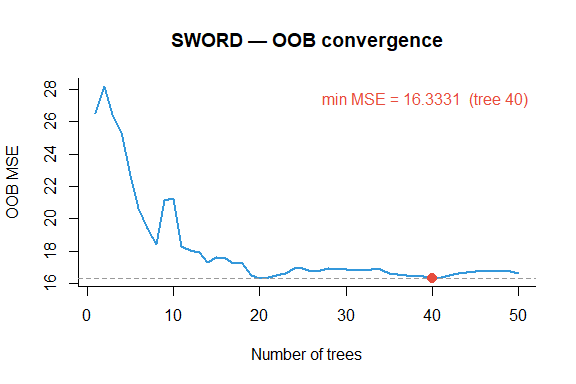

```r
plot(forest, which = "oob")
```

### OOB predicted vs. observed

`plot_oob_fit()` plots the out-of-bag predictions against the true training responses. Points on the identity line indicate perfect fit; the annotation reports RMSE, MAE, and R.

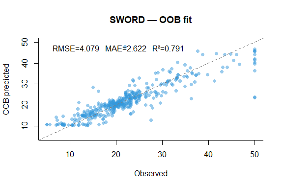

```r
plot_oob_fit(forest, y_train)
```

## Prediction on the test set

```r
y_hat <- predict(forest, X_test)

rmse <- sqrt(mean((y_hat - y_test)^2))
mae  <- mean(abs(y_hat - y_test))
r2   <- cor(y_hat, y_test)^2

cat(sprintf("Test RMSE : %.3f\n", rmse))
```

```
#> Test RMSE : 3.513
```

```r
cat(sprintf("Test MAE  : %.3f\n", mae))
```

```
#> Test MAE  : 2.187
```

```r
cat(sprintf("Test R^2  : %.3f\n", r2))
```

```
#> Test R^2  : 0.889
```

The `predict()` method also accepts a `data.frame` that contains extra columns (e.g. the response), so you can pass the original data frame directly:

```r
y_hat2 <- predict(forest, Boston[test, ])  # medv column is silently dropped
all.equal(y_hat, y_hat2)
```

```
#> [1] TRUE
```

## Variable importance

`VI_SWORD()` computes the **OIW-VI** (Oblique Impurity-Weighted Variable Importance): at each internal node, the deviance reduction is distributed among the predictors involved in the oblique split proportionally to their normalised absolute Weighted-SVM coefficients; these scores are then averaged across all trees. `plot_vi_sword()` draws a horizontal barplot sorted by importance.

```r
vi <- VI_SWORD(forest)
print(round(vi, 2))
```

```
#>   lstat      rm ptratio     rad     tax     dis    crim     nox     age   indus
#> 9379.85 5071.10 2483.61 1969.78 1671.69 1653.34 1513.40 1407.63 1134.42  931.68
#>   black      zn    chas
#>  662.70  463.94  364.77
```

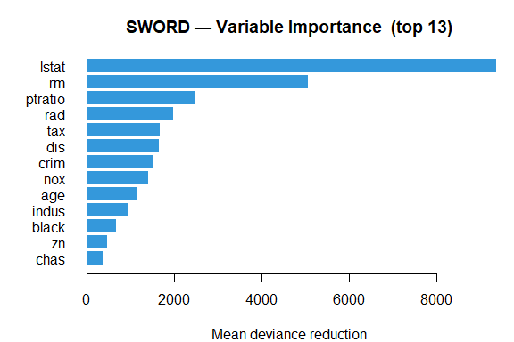

```r
plot_vi_sword(forest, top_n = 13)
```

## Partial dependence plots

`pdp_sword()` computes the marginal effect of a single predictor by fixing it to a grid of values and averaging forest predictions over the full training set (Friedman 2001). A rug of observed values is added by default.

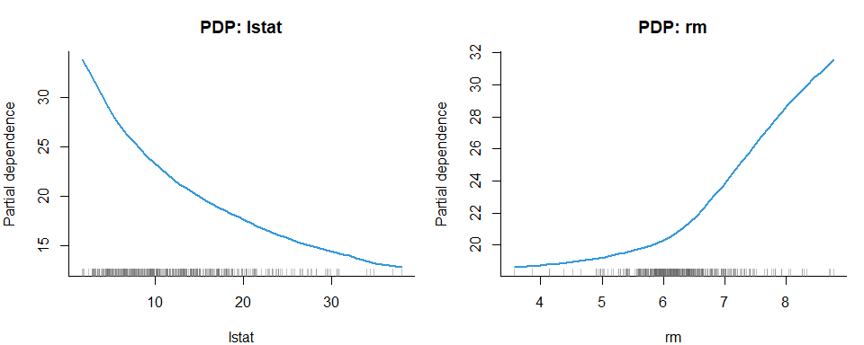

```r
old_par <- par(mfrow = c(1, 2), mar = c(4, 4, 3, 1))
pdp_sword(forest, X_train, "lstat", main = "PDP: lstat")
pdp_sword(forest, X_train, "rm",    main = "PDP: rm")
```

```r
par(old_par)
```

Top-4 predictors in a 2x2 grid:

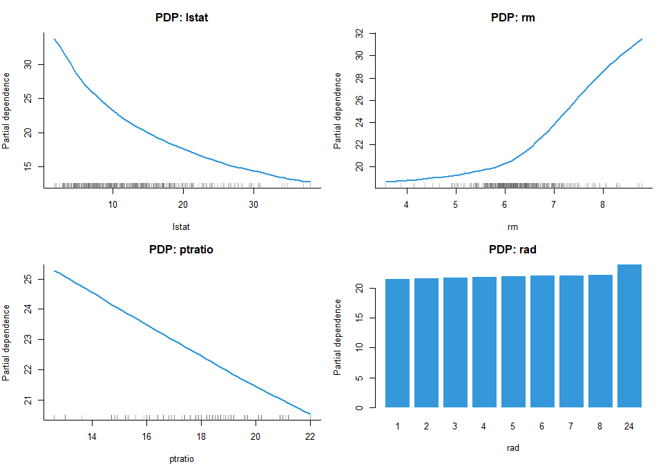

```r
top4 <- names(vi)[1:4]
old_par <- par(mfrow = c(2, 2), mar = c(4, 4, 3, 1))
for (v in top4)
  pdp_sword(forest, X_train, v, main = paste("PDP:", v))
```

```r
par(old_par)
```

## Parameter sensitivity in SWORD

Four parameters most likely to affect predictive accuracy are `relation`, `Weight_Scheme`, `rf_var`, and `rand_ntopcor`. In this section we fit compact forests (`m = 20`, `nmin = 10`, `cp = 0.01`) varying each parameter in turn and compare test-set RMSE on the same Boston hold-out.

### Feature selection criterion: `relation`

`relation` controls how the top-correlated features are identified at each node: `"Pearson"` uses the absolute Pearson correlation with the node residuals; `"MI"` uses mutual information, which can capture non-linear associations between each predictor and the response.

```r
set.seed(42)
f_pearson <- SWORD(X_train, y_train, m = 20, nmin = 10, cp = 0.01,
                   relation = "Pearson", verbose = FALSE)
set.seed(42)
f_mi      <- SWORD(X_train, y_train, m = 20, nmin = 10, cp = 0.01,
                   relation = "MI",      verbose = FALSE)

cat(sprintf("Pearson  — test RMSE: %.3f\n", rmse_f(y_test, predict(f_pearson, X_test))))
```

```
#> Pearson  — test RMSE: 3.534
```

```r
cat(sprintf("MI       — test RMSE: %.3f\n", rmse_f(y_test, predict(f_mi,      X_test))))
```

```
#> MI       — test RMSE: 3.516
```

Both criteria are competitive on continuous predictors; `"MI"` may offer an advantage when predictor–response associations are strongly non-linear.

### Observation weighting: `Weight_Scheme`

`Weight_Scheme` determines how observations are weighted when fitting the Weighted-SVM at each node. Both schemes assign higher weight to observations whose response is far from the local centre, guiding the SVM to concentrate on the most informative thresholds. The two formulas differ in how the centre and spread are estimated:

$$w_i^{\text{scale}} = \frac{|y_i - \bar{y}|}{s_y}, \qquad
w_i^{\text{robust}} = \frac{|y_i - \text{median}(y)|}{\text{MAD}(y)}$$

where $s_y$ is the standard deviation and $\text{MAD}(y) = \text{median}(|y_i - \text{median}(y)|)$. Because `"robust"` centres on the median and scales by the MAD rather than the mean and standard deviation, it is less influenced by extreme values in the response.

```r
set.seed(42)
f_scale  <- SWORD(X_train, y_train, m = 20, nmin = 10, cp = 0.01,
                  Weight_Scheme = "scale",  verbose = FALSE)
set.seed(42)
f_robust <- SWORD(X_train, y_train, m = 20, nmin = 10, cp = 0.01,
                  Weight_Scheme = "robust", verbose = FALSE)

cat(sprintf("scale    — test RMSE: %.3f\n", rmse_f(y_test, predict(f_scale,  X_test))))
```

```
#> scale    — test RMSE: 3.534
```

```r
cat(sprintf("robust   — test RMSE: %.3f\n", rmse_f(y_test, predict(f_robust, X_test))))
```

```
#> robust   — test RMSE: 3.596
```

`"robust"` is recommended when the training response contains outliers or extreme values that would inflate $s_y$ and distort the `"scale"` weights.

### Feature subsampling per split: `rf_var`

`rf_var` sets how many predictors are randomly sub-sampled at each node before the top-`n_topCor` correlated ones are selected for the SVM. Reducing `rf_var` increases tree decorrelation — analogously to `mtry` in standard random forests. Three common choices with `p = 13` predictors:

```r
set.seed(42)
f_full <- SWORD(X_train, y_train, m = 20, nmin = 10, cp = 0.01,
                rf_var = p,               verbose = FALSE)  # all predictors
set.seed(42)
f_half <- SWORD(X_train, y_train, m = 20, nmin = 10, cp = 0.01,
                rf_var = floor(p / 2),    verbose = FALSE)  # half
set.seed(42)
f_sqrt <- SWORD(X_train, y_train, m = 20, nmin = 10, cp = 0.01,
                rf_var = floor(sqrt(p)),  verbose = FALSE)  # sqrt rule

cat(sprintf("rf_var = %2d (all)        — test RMSE: %.3f\n",
            p,               rmse_f(y_test, predict(f_full, X_test))))
```

```
#> rf_var = 13 (all)        — test RMSE: 3.534
```

```r
cat(sprintf("rf_var = %2d (floor p/2)  — test RMSE: %.3f\n",
            floor(p / 2),   rmse_f(y_test, predict(f_half, X_test))))
```

```
#> rf_var =  6 (floor p/2)  — test RMSE: 3.842
```

```r
cat(sprintf("rf_var = %2d (floor sqrt) — test RMSE: %.3f\n",
            floor(sqrt(p)), rmse_f(y_test, predict(f_sqrt, X_test))))
```

```
#> rf_var =  3 (floor sqrt) — test RMSE: 4.416
```

### Randomised top-feature cardinality: `rand_ntopcor`

```r
set.seed(42)
f_rnd_t <- SWORD(X_train, y_train, m = 20, nmin = 10, cp = 0.01,
                 rand_ntopcor = TRUE,  verbose = FALSE)
set.seed(42)
f_rnd_f <- SWORD(X_train, y_train, m = 20, nmin = 10, cp = 0.01,
                 rand_ntopcor = FALSE, verbose = FALSE)

cat(sprintf("rand_ntopcor = TRUE  — test RMSE: %.3f\n",
            rmse_f(y_test, predict(f_rnd_t, X_test))))
```

```
#> rand_ntopcor = TRUE  — test RMSE: 3.534
```

```r
cat(sprintf("rand_ntopcor = FALSE — test RMSE: %.3f\n",
            rmse_f(y_test, predict(f_rnd_f, X_test))))
```

```
#> rand_ntopcor = FALSE — test RMSE: 3.766
```

Randomisation usually helps when `m` is large enough; for very small forests it can occasionally hurt by introducing excess variance.

### Summary comparison

```
#>      Parameter                  Value Test_RMSE
#>       relation      Pearson (default)     3.534
#>       relation                     MI     3.516
#>  Weight_Scheme        scale (default)     3.534
#>  Weight_Scheme                 robust     3.596
#>         rf_var p = 13 — all (default)     3.534
#>         rf_var         floor(p/2) = 6     3.842
#>         rf_var     floor(sqrt(p)) = 3     4.416
#>   rand_ntopcor         TRUE (default)     3.534
#>   rand_ntopcor                  FALSE     3.766
```

## Categorical and character predictors

SWORD handles factor and character columns automatically: they are one-hot-encoded internally, new factor levels in `predict()` are mapped to all-zero dummies, and `VI_SWORD()` sums dummy-column importances back to the original variable name.

```r
data(diamonds, package = "ggplot2")
set.seed(7)
idx   <- sample(nrow(diamonds), 2000)
X_dia <- diamonds[idx, c("carat","cut","color","clarity",
                          "depth","table","x","y","z")]
y_dia <- diamonds$price[idx]

forest_dia <- SWORD(X_dia, y_dia, m = 50, OOB = TRUE, verbose = FALSE)
print(forest_dia)

# VI grouped by original variable (not by dummy column)
VI_SWORD(forest_dia)

# PDP for an ordered factor
pdp_sword(forest_dia, X_dia, "cut")
```

## Formula interface

Both `TORS()` and `SWORD()` accept an R formula with a `data` argument:

```r
df <- cbind(X_train, medv = y_train)

tree2   <- TORS(medv ~ ., data = df, nmin = 15, cp = 0.02)
forest2 <- SWORD(medv ~ ., data = df, m = 50, verbose = FALSE)
predict(forest2, Boston[test, ])
```

## Summary

| Task | Function |
| --- | --- |
| Fit one tree | `TORS(X, y)` |
| Fit a forest | `SWORD(X, y, m = 100)` |
| Predict | `predict(forest, newdata)` |
| OOB convergence | `plot(forest, which = "oob")` |
| OOB scatter | `plot_oob_fit(forest, y)` |
| OIW-VI (variable importance) | `VI_SWORD(forest)` / `plot_vi_sword(forest)` |
| Partial dependence | `pdp_sword(forest, X, "varname")` |
| Tree text print | `plot_tors_text(tree)` |
| Tree graph | `plot(tree)` |

## References

Carta, A. and Frigau, L. (2025). Tree oblique for regression with weighted support vector machine. *Computational Statistics*, **40**, 5257–5291. https://doi.org/10.1007/s00180-025-01647-w

Yang, X., Song, Q. and Cao, A. (2005). Weighted support vector machine for data classification. In *Proceedings of the 2005 IEEE International Joint Conference on Neural Networks (IJCNN)*. https://doi.org/10.1109/IJCNN.2005.1555965

Xu, T. et al. (2024). *WeightSVM: Subject/Instance Weighted Support Vector Machines*. R package version 1.7-16. https://doi.org/10.32614/CRAN.package.WeightSVM